# Resampling Methods

Yunsheng Lu

2023-01-05

# Cross-Validation

Cross-Validation(交叉验证)是一种利用数据集本身来衡量对模型对数据集本身预测准确性的一种方法。

### Validation Approach

Validation Approach粗暴地将数据分成testing set和training set两部分。而后利用对training set来估计testing set来估计error rate。是的，这是最简单粗暴的方法。优点是计算量较小，缺点是error rate估计偏高，并且估计的波动较大。

```r
library(ISLR2)
head(Auto)
```

```
##   mpg cylinders displacement horsepower weight acceleration year origin
## 1  18         8          307        130   3504         12.0   70      1
## 2  15         8          350        165   3693         11.5   70      1
## 3  18         8          318        150   3436         11.0   70      1
## 4  16         8          304        150   3433         12.0   70      1
## 5  17         8          302        140   3449         10.5   70      1
## 6  15         8          429        198   4341         10.0   70      1
##                        name
## 1 chevrolet chevelle malibu
## 2         buick skylark 320
## 3        plymouth satellite
## 4             amc rebel sst
## 5               ford torino
## 6          ford galaxie 500
```

```r
attach(Auto)
#use sample( ) to select a training and a testing dataset
set.seed(1)
train<-sample(392,196) #randomly select 196 points out of 392
lm.fit<-lm(mpg~horsepower,subset=train)
lm.fit2<-lm(mpg~poly(horsepower,2),subset=train)
lm.fit3<-lm(mpg~poly(horsepower,3),subset=train)
#calculate mean sum of errors for each fitting on testing data
mean((mpg-predict(lm.fit, Auto))[-train]^2)
```

```
## [1] 23.26601
```

```r
mean((mpg-predict(lm.fit2, Auto))[-train]^2)
```

```
## [1] 18.71646
```

```r
mean((mpg-predict(lm.fit3, Auto))[-train]^2)
```

```
## [1] 18.79401
```

### Leave-one-out Cross-Validation

假设一个数据集有n个点。Leave-one-out Approach(LOOCV)是将这n个数据点以此看作n个单个点数据集看作testing dataset(每次利用剩下的n-1个数据点训练模型)。因此利用公式得到$CV_{(n)}=\frac{1}{n}\sum_{i=1}^n MSE_i$,其中$MSE_{i}=(y_i-\hat{y}_{i})^2$,而$\hat{y}_i$是通过不包括$y_i$的training set训练得到的对$y_i$的估计。 若fitting model选取的是least-square linear regression或polynomial regression, 那么可以根据以下公式计算:$CV_{(n)}=\frac{1}{n}\sum_{i=1}^n(\frac{y_i-\hat{y}_i}{1-h_i})^2$。这个方法的优点是bias将会非常小。但是有两个缺点：首先计算量十分大；其次variance可能会很高。

```r
#cv.glm( ) is in boot library
library(boot)
glm.fit<-glm(mpg~horsepower)
#use cv.glm( ) to get cv results. It produces several components.
cv.err<-cv.glm(Auto,glm.fit)
#delta vector contains the cross-validation result (the error rate) The first component is the raw cross-validation estimate of prediction error. The second component is the adjusted estimate, adjusted to the bias introduced by not using LOOCV.
cv.err$delta
```

```
## [1] 24.23151 24.23114
```

```r
#Another example
cv.error<-rep(0,10)
for(i in 1:10){
  glm.fit<-glm(mpg~poly(horsepower,i))
  cv.error[i]<-cv.glm(Auto,glm.fit)$delta[1]
}
cv.error
```

```
##  [1] 24.23151 19.24821 19.33498 19.42443 19.03321 18.97864 18.83305 18.96115
##  [9] 19.06863 19.49093
```

### K-fold Cross-Validation

K-fold交叉验证可谓是结合前两者的优点于一身。我们将原本的dataset分成k个subsets。每次利用k-1个datasets进行训练，并用剩下的一个进行测试，每次得到的Mean Squared Errors取平均，即：$CV_{(k)}=\frac{1}{k}\sum_{i=1}^kMSE_i$.

```r
#cv.glm( ) is in boot library
library(boot)
cv.error.10<-rep(0,10)
for(i in 1:10){
  glm.fit<-glm(mpg~poly(horsepower,i))
  cv.error.10[i]<-cv.glm(Auto,glm.fit,K=10)$delta[1]
}
cv.error.10
```

```
##  [1] 24.17411 19.33921 19.47562 19.55279 19.29816 19.01989 19.19994 19.57030
##  [9] 19.10103 19.64224
```

# Bootstrap

Bootstrap(自举法)是一种利用数据集本身来衡量对数据集本身的参数估计的波动性的方法。若数据集包含n个数据点，那么每次随机选取n个可重复的数据点组成B个数据集$Z^{*r}$,并利用$Z^{*r}$估计参数$\hat{\alpha}$,记作$\alpha^{*r}$.其中$\hat{\alpha}^{*r}$可由$Z^{*r}$内部的自举法得到。我们利用此公式来计算标准误差：$SE_B(\hat{\alpha})=\sqrt{\frac{1}{B-1}\sum_{i=1}^B(\hat{\alpha}^{*i}-\frac{1}{B}\sum_{j=1}^B\hat{\alpha}^{*j})^2}$

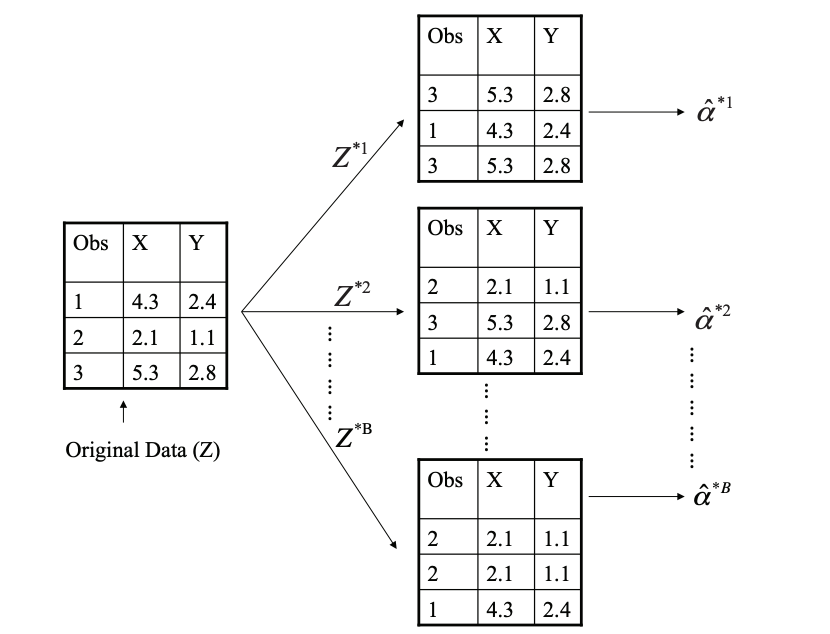

### Example 1–Estimating the accuracy of a statistic of interests

The parameter that we want to estimate refers to ISLR section 5.2., the following function calculate the parameter a by the formula:

```r
alpha.fn<-function(data,index){
  X<-data$X[index]
  Y<-data$Y[index]
  (var(Y)-cov(X,Y)) / (var(X)+var(Y)-2*cov(X,Y))
}
head(Portfolio)
```

```
##            X          Y
## 1 -0.8952509 -0.2349235
## 2 -1.5624543 -0.8851760
## 3 -0.4170899  0.2718880
## 4  1.0443557 -0.7341975
## 5 -0.3155684  0.8419834
## 6 -1.7371238 -2.0371910
```

```r
alpha.fn(Portfolio,1:100)
```

```
## [1] 0.5758321
```

```r
#We use boot( ) to perform a bootstrap analysis
boot(Portfolio,alpha.fn,R=1000) # number of Z^i is 1000 in total
```

```
##
## ORDINARY NONPARAMETRIC BOOTSTRAP
##
##
## Call:
## boot(data = Portfolio, statistic = alpha.fn, R = 1000)
##
##
## Bootstrap Statistics :
##      original       bias    std. error
## t1* 0.5758321 -0.001949125  0.09205834
```

### Example 2–Estimating the accuracy of a statistics of interests

We fit mpg using horsepower and we introduce two methods

```r
#Method 1
#boot.fn用于“帮助”我们对给定bootstrap dataset进行估计
boot.fn<-function(data,index){
  coef(lm(mpg~horsepower,data=data,subset=index))
}
boot.fn(Auto,1:392)
```

```
## (Intercept)  horsepower
##  39.9358610  -0.1578447
```

```r
set.seed(1) #We need seed because boot create random datasets
boot.fn(Auto,sample(392,392,replace = TRUE)) #replace=true means repetition is allowed，因此我们创建了一个基于原本dataset但是points可重复的新的dataset
```

```
## (Intercept)  horsepower
##  40.3404517  -0.1634868
```

```r
#Method 2, which will include the standard errors of 1000 bootstrap estimates of the intercept and slope
boot(Auto,boot.fn,1000) #Bootstrap with R=1000
```

```
##
## ORDINARY NONPARAMETRIC BOOTSTRAP
##
##
## Call:
## boot(data = Auto, statistic = boot.fn, R = 1000)
##
##
## Bootstrap Statistics :
##       original        bias    std. error
## t1* 39.9358610  0.0549915227 0.841925746
## t2* -0.1578447 -0.0006210818 0.007348956
```

Note that lm( ) 当中似乎有直接对于估计的参数的standard error的记录

```r
summary(lm(mpg~horsepower,data=Auto))$coef
```

```
##               Estimate  Std. Error   t value      Pr(>|t|)
## (Intercept) 39.9358610 0.717498656  55.65984 1.220362e-187
## horsepower  -0.1578447 0.006445501 -24.48914  7.031989e-81
```

但是为什么上面得到的结果与我们bootstrap的结果不用呢？其实，我们在使用lm( )时假设error term是normally distributed，这可不一定对哦